# Exploratory analysis of OP006 operant data

JeremyMetha & MathildeBertheau

26/07/2019

# 1 Sort out the Data and Create the Timeresponse column

```r
arm1 <- arm1 %>%
  group_by(Day, Subject) %>%
  arrange(Trial) %>%
  mutate(Timebetween = (Time - lag(Time))*0.1) # Calculate the time between each presses (in seconds)



sortarm1 <- arrange(arm1, Subject, Day, Time) # Sort out the data

head(sortarm1)
```

| X | Treatment | Subject | Task | Time | Choice | Reward | Trial | Day | Ones | AllTrials | Timebetween |
| --- | --- | --- | --- | --- | --- | --- | --- | --- | --- | --- | --- |
| 1 | T | 1.1 | 0P005_WTL | 55 | -1 | 1 | 1 | 1 | 1 | 1 | NA |
| 405 | T | 1.1 | 0P005_WTL | 159 | 1 | 1 | 2 | 1 | 1 | 2 | 10.4 |
| 807 | T | 1.1 | 0P005_WTL | 249 | -1 | -1 | 3 | 1 | 1 | 3 | 9.0 |
| 1206 | T | 1.1 | 0P005_WTL | 319 | 1 | 1 | 4 | 1 | 1 | 4 | 7.0 |
| 1600 | T | 1.1 | 0P005_WTL | 391 | -1 | 1 | 5 | 1 | 1 | 5 | 7.2 |
| 1993 | T | 1.1 | 0P005_WTL | 462 | -1 | 1 | 6 | 1 | 1 | 6 | 7.1 |

# 2 Creation of the Variable Mean of the time needed for pressing a lever for all trials

```r
#head(arm1)

#sortarm1 %>%
#  group_by(Day) %>%
#  mutate(mean_timeb = mean(Timebetween, na.rm = TRUE)) %>%
#  select(Subject, Day, mean_timeb)

TBD <- sortarm1 %>%
  group_by(Day, Subject) %>%
  summarise(mean_timeb = mean(Timebetween, na.rm=TRUE)) # New frame with the mean of timebetween for each day and each mouse.
```

# 3 Analyse on Each Mouse

## 3.1 Mouse 1.1

```r
M <- arm1[arm1$Subject=='1.1' ,]
summary(M)
```

```
##        X         Treatment    Subject           Task          Time
##  Min.   :    1   S:  0     Min.   :1.1   0P005_WTL:479   Min.   :   53
##  1st Qu.: 9068   T:979     1st Qu.:1.1   0P005_WTR:500   1st Qu.: 3167
##  Median :17322             Median :1.1                   Median : 5231
##  Mean   :17097             Mean   :1.1                   Mean   : 5209
##  3rd Qu.:25330             3rd Qu.:1.1                   3rd Qu.: 7314
##  Max.   :32703             Max.   :1.1                   Max.   :10813
##
##      Choice            Reward            Trial             Day
##  Min.   :-1.0000   Min.   :-1.0000   Min.   :  1.00   Min.   : 1.000
##  1st Qu.: 1.0000   1st Qu.:-1.0000   1st Qu.: 25.00   1st Qu.: 3.000
##  Median : 1.0000   Median : 1.0000   Median : 49.00   Median : 6.000
##  Mean   : 0.6507   Mean   : 0.3778   Mean   : 49.65   Mean   : 5.554
##  3rd Qu.: 1.0000   3rd Qu.: 1.0000   3rd Qu.: 74.00   3rd Qu.: 8.000
##  Max.   : 1.0000   Max.   : 1.0000   Max.   :100.00   Max.   :10.000
##                    NA's   :5
##       Ones     AllTrials      Timebetween
##  Min.   :1   Min.   :  1.0   Min.   :  0.400
##  1st Qu.:1   1st Qu.:245.5   1st Qu.:  7.300
##  Median :1   Median :490.0   Median :  8.200
##  Mean   :1   Mean   :490.0   Mean   :  9.018
##  3rd Qu.:1   3rd Qu.:734.5   3rd Qu.:  9.300
##  Max.   :1   Max.   :979.0   Max.   :105.000
##                              NA's   :10
```

```r
table(M$Choice)
```

```
##
##  -1   1
## 171 808
```

```r
table(M$Reward)
```

```
##
##  -1   1
## 303 671
```

```r
ML <- subset(arm1, Subject=='1.1' & Task=='0P005_WTL')
dim(ML)
```

```
## [1] 479  12
```

```r
table(ML$Choice)
```

```
##
##  -1   1
##  44 435
```

```r
MR <- subset(arm1, Subject=='1.1' & Task=='0P005_WTR')
dim(MR)
```

```
## [1] 500  12
```

```r
table(MR$Choice)
```

```
##
##  -1   1
## 127 373
```

```r
Nb_pres <- count(M, Choice, Day)
names(Nb_pres)[1] <- "Lever"
Nb_pres$Lever[Nb_pres$Lever==-1] <- "Low_lever"
Nb_pres$Lever[Nb_pres$Lever==1] <- "High_lever"
names(Nb_pres)[2] <- "day"
Nb_pres
```

| Lever | day | Choice | n |
| --- | --- | --- | --- |
| High_lever | 1.1 | -1 | 27 |
| High_lever | 1.1 | 1 | 73 |
| 2 | 1.1 | -1 | 10 |
| 2 | 1.1 | 1 | 90 |
| 3 | 1.1 | -1 | 1 |
| 3 | 1.1 | 1 | 78 |
| 4 | 1.1 | -1 | 4 |
| 4 | 1.1 | 1 | 96 |
| 5 | 1.1 | -1 | 2 |
| 5 | 1.1 | 1 | 98 |

[output cut: 10 more lines]

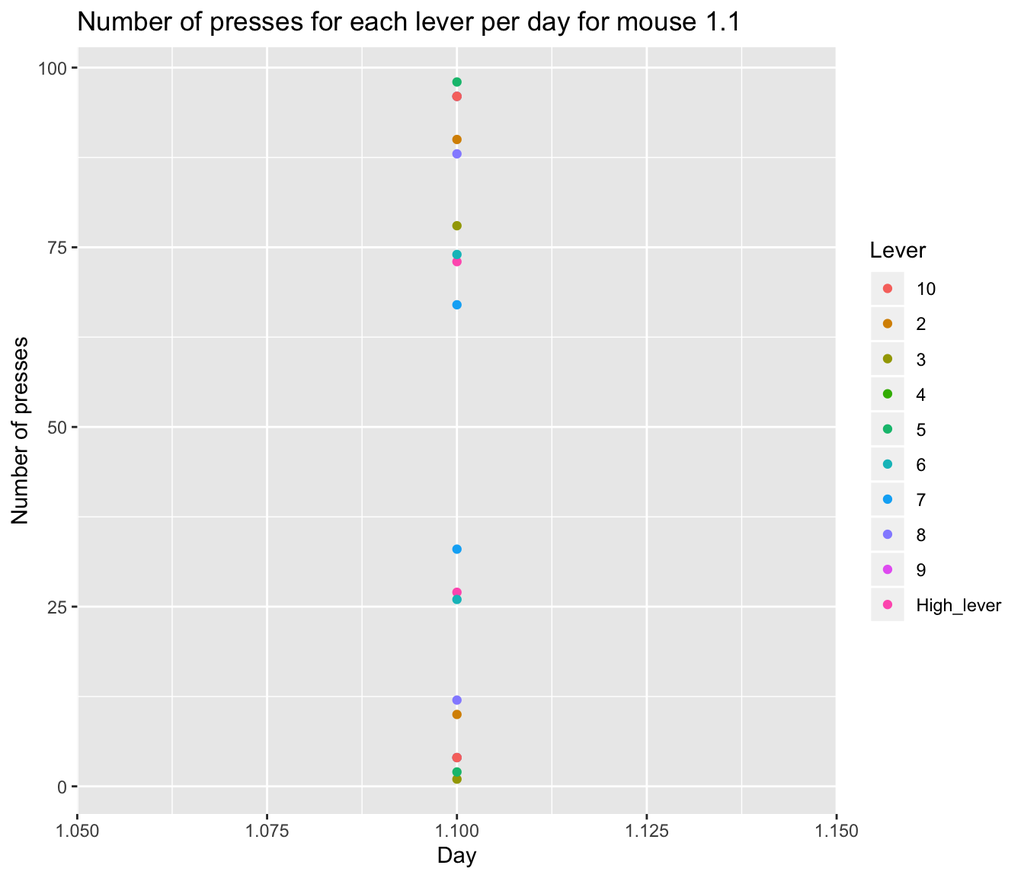

```r
quickplot(x=day, y=n, data = Nb_pres, color = Lever) +
  labs(y = "Number of presses",
       x = "Day",
       title = "Number of presses for each lever per day for mouse 1.1")# Graph number of presses on each
```

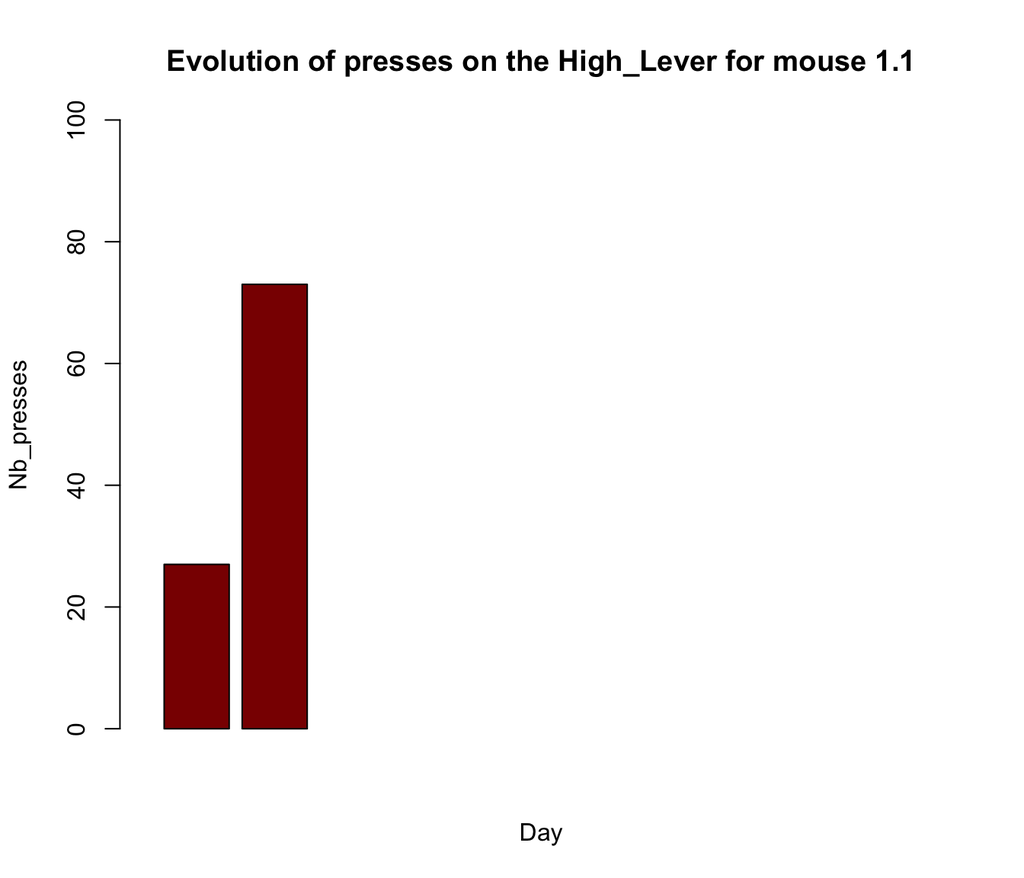

```r
ggsave("Number of presses for each lever per day for mouse 1.1.png", width = 11, height = 8)


HL <- filter(Nb_pres,Lever=='High_lever')
barplot(HL$n, xlab='Day', ylab='Nb_presses', col ='darkred', main='Evolution of presses on the High_Lever for mouse 1.1',xlim=c(0,12), ylim=c(0,100))
```

[figure not shown]

```r
LL <- filter(Nb_pres,Lever=='Low_lever')
barplot(LL$n, xlab='Day', ylab='Nb_presses', col ='darkblue', main='Evolution of presses on the Low_Lever for mouse 1.1',xlim=c(0,12), ylim=c(0,100) )
```

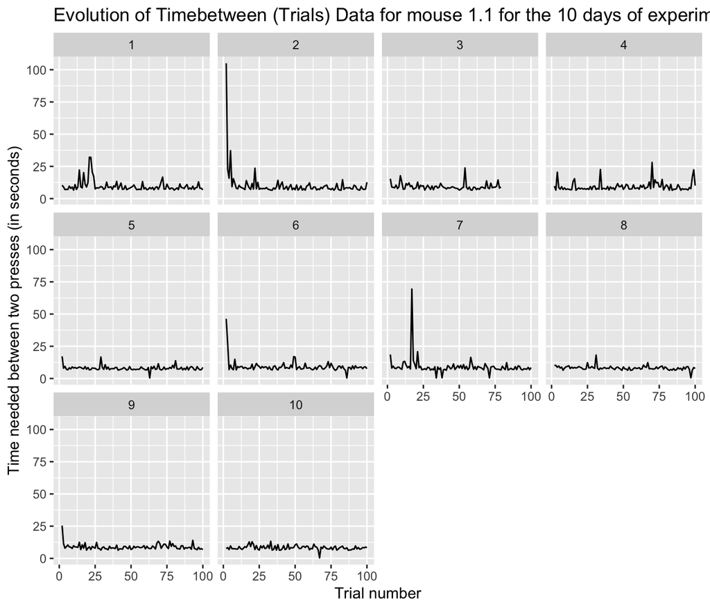

```r
dM <- filter(sortarm1,Subject=='1.1')


qplot(Trial, Timebetween, data = dM, geom='line') +
  facet_wrap(~ Day) +
  labs(y = "Time needed between two presses (in seconds)",
       x = "Trial number",
       title = "Evolution of Timebetween (Trials) Data for mouse 1.1 for the 10 days of experiment")
```

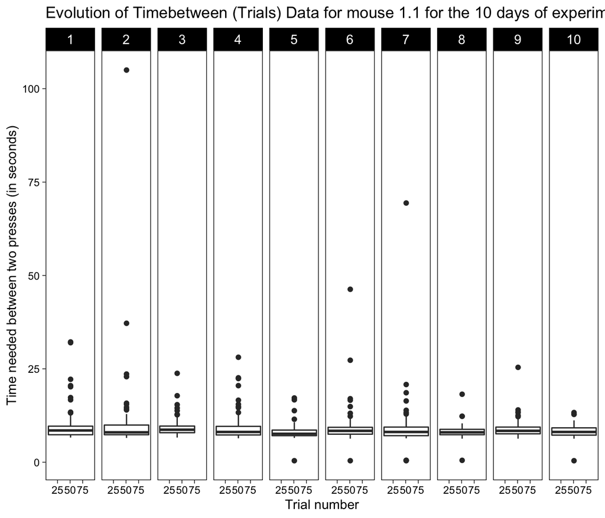

```r
# Graphs showing the evolution of time between per trial for each day

ggplot(data = dM, aes(x = Trial, y = Timebetween)) +
  geom_boxplot() +
  facet_grid(. ~ Day) +
  labs(y = "Time needed between two presses (in seconds)",
       x = "Trial number",
       title = "Evolution of Timebetween (Trials) Data for mouse 1.1 for the 10 days of experiment") +
  theme_linedraw() +
  theme(strip.text = element_text(size = rel(1)),
        panel.grid = element_blank())
```

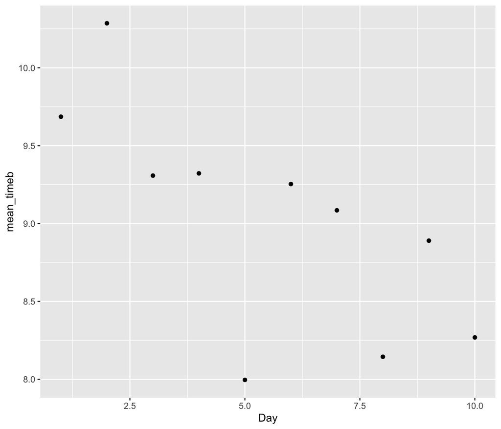

```r
M1 <- filter(TBD, Subject=='1.1')
ggplot(M1) + geom_point(aes(x = Day, y = mean_timeb))
```

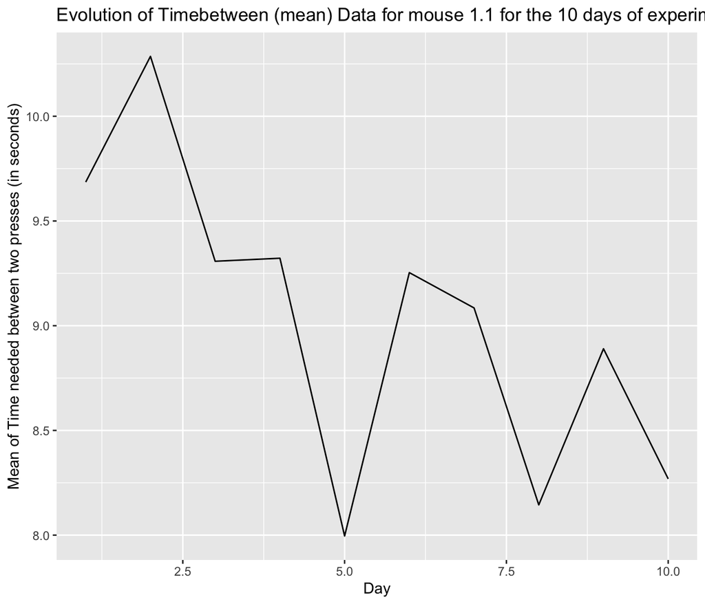

```r
gM1 <- ggplot(M1) + geom_line(aes(x = Day, y = mean_timeb)) +
  labs(y = "Mean of Time needed between two presses (in seconds)",
       x = "Day",
       title = "Evolution of Timebetween (mean) Data for mouse 1.1 for the 10 days of experiment")
gM1
```

Mouse 1.1 is a smart one. (Cf.Learning-Analysis) On TPGS treatment. The maximum number of trials is around 1000 (10 times 100 presses). He pressed 979 on 1000 trials. Among these 979 presses, 808 were the high rewarded lever and only 171 on the low lever. During the reversal phase (WTR), mouse 1.1 pressed 100 times the lever each 5 days. We can see that during the WTL session, he pressed 435/479 (90,8%) the high lever and 44/479 (9,2%) the low lever while during the reversal phase (WTR), he pressed 373/500 (74,6%) the high lever and 127/500 (25,4%) the low lever. The probability of success is obviously much better before the reversal.

Graphs :

The time of response decrease from day 2 to 5. (from 10,3s to 8s). We can see an increase of the time of response on day 6, which is the first day of reversal. Then the time of response decrease again to 8,25s.